# Project Overview

## Project Overview

The value of *Bitcoin* has increased a lot since it was invented. Also, more and more people are interested in investing in *Bitcoin*. It seems interesting to invetigate the factors that affec the price.

This project perform a simple analysis on the effect of two factors on *Bitcoin* price.

## Research Question

- Does the difficulty to find a new block affect the price of *Bitcoin*?
- Does the volume of the *Bitcoin* affect the price of *Bitcoin*?

## Hypothesis

- The price of *Bitcoin* would be higher with increasing difficulty to find a new block because lower supplies (new blocks) makes *Bitcoin* more valuable.
- The volume of the *Bitcoin* would positively affect the price of *Bitcoin* because higher the volume, more investors would like to buy it.

## Data

Let's take a look at the data frame for analysis. `Close` is the daily closing price of *Bitcoin* from 2013-4-28 to 2017-11-07. `btc_difficulty` is a relative measure of the difficulty in finding a new block. `Volume` is the volume of transactions on the given day.

```
## # A tibble: 6 x 4
##         Date   Close btc_difficulty     Volume
##       <dttm>   <dbl>          <dbl>      <dbl>
## 1 2017-11-07 7144.38    1.45284e+12 2326340000
## 2 2017-11-06 7022.76    1.45284e+12 3111900000
## 3 2017-11-05 7407.41    1.45284e+12 2380410000
## 4 2017-11-04 7379.95    1.45284e+12 2483800000
## 5 2017-11-03 7207.76    1.45284e+12 3369860000
## 6 2017-11-02 7078.50    1.45284e+12 4653770000
```

Below is the pair-plots for these 3 variables. We can see that both `Volume` and `btc_difficulty` are positively correlated with the price `Close`.

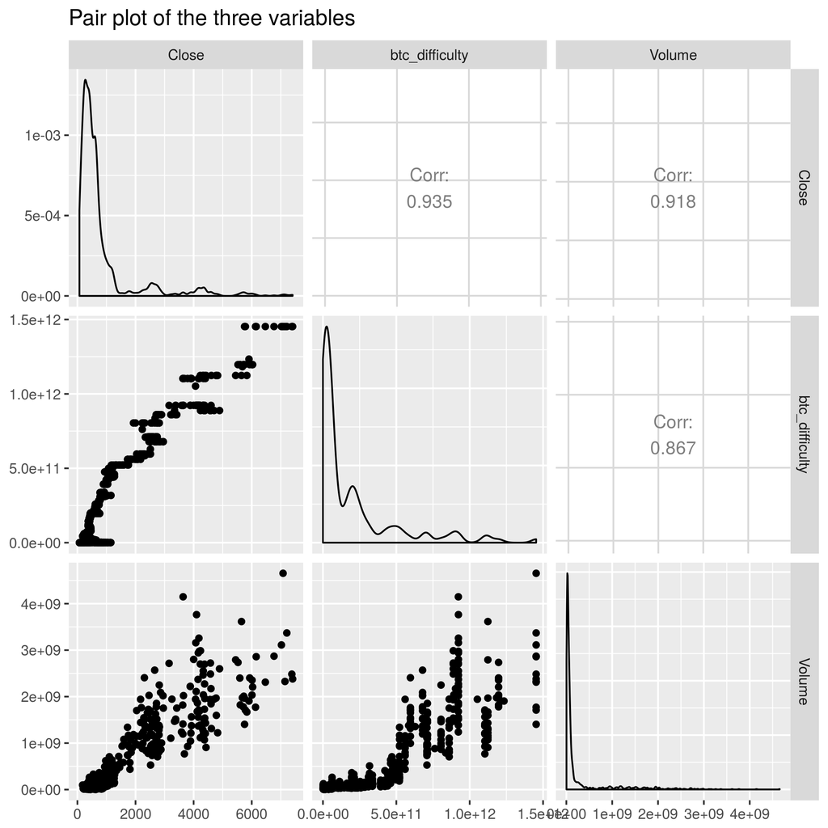

## Analysis

Here we will first look at some descriptive statistics of the data.

```
## # A tibble: 28 x 3
##     Var1  Var2                        Freq
##    <chr> <chr>                       <chr>
##  1  <NA>  Date Min.   :2013-04-28 00:00:00
##  2  <NA>  Date 1st Qu.:2014-06-15 12:00:00
##  3  <NA>  Date Median :2015-08-03 00:00:00
##  4  <NA>  Date Mean   :2015-08-03 00:00:00
##  5  <NA>  Date 3rd Qu.:2016-09-19 12:00:00
##  6  <NA>  Date Max.   :2017-11-07 00:00:00
##  7  <NA>  Date                        <NA>
##  8  <NA> Close             Min.   :  68.43
##  9  <NA> Close             1st Qu.: 264.13
## 10  <NA> Close             Median : 453.38
## # ... with 18 more rows
```

We can see that there are a big range for three groups of the variable (except `Date`). But we cannot really get any conclusions from the table above. Here below let's perform a regression analysis.

```
## # A tibble: 4 x 5
##                    term      estimate    std.error statistic       p.value
##                   <chr>         <dbl>        <dbl>     <dbl>         <dbl>
## 1           (Intercept)  2.667166e+02 9.889656e+00 26.969250 1.707039e-129
## 2        btc_difficulty  2.099300e-09 4.818360e-11 43.568770 2.837285e-263
## 3                Volume -2.110627e-07 4.588188e-08 -4.600132  4.601666e-06
## 4 btc_difficulty:Volume  1.101815e-18 4.158002e-20 26.498663 7.266806e-126
```